# NYMEX Crystal Ball

Predicting Prompt-Month Natural Gas Prices

Author

Nate Garozzo

Published

August 5, 2026

## Overview

This model predicts the path that the prompt-month Henry Hub natural gas contract will take over the next $h$ trading days, where $5 < h < 45$. The predicted price path is supplemented by 60% and 90% confidence intervals, giving the full range of expected outcomes for a given prediction window.

Natural gas prices are among the most difficult commodity prices to forecast, since short-term movement is largely driven by factors such as storage reports, geopolitical surprises, weather model updates, and pipeline flow data. Access to expensive and proprietary data/information is usually required in order to beat out the market before these factors are priced in. In addition, prices are especially volatile during winter months, when the market is especially sensitive to signals, and fundamental conditions are subject to dramatic change.

This project is built entirely upon free data, which means its performance is generally strongest when $30 < h < 45$. This medium/long-term horizon is when fundamental signals dominate relative to market noise. Furthermore, the model provides far more value when forecasting in summer/shoulder months (Mar-Nov) than winter months (Dec-Feb). The model’s performance is evaluated in two ways:

1. **Directional accuracy** - Whether or not the model’s bullish or bearish prediction aligned with the actual direction of price movement.
2. **Random walk** - How the model’s point forecast performs relative to the random walk benchmark. The random walk assumes that $\text{tomorrow's price} = \text{today's price}$. This benchmark is used across many natural gas price prediction models to evaluate performance. It is surprisingly hard to beat the random walk, so even a slight edge means that the model is adding value.

The model achieves 70.4% directional accuracy in summer and 68.0% in fall at $h = 45$ with an overall directional accuracy of 63.9% across 1,251 trading day origins. It also beats the random walk on magnitude $|\text{actual price} - \text{predicted price}|$ with a median RMSPE across summer and shoulder months of 0.874, meaning on average the model’s forecast errors are 12.6% smaller than the random walk. Performance is noticeably worse in winter months, where directional accuracy falls to 50.8% and median RMSPE rises to 1.220. The model is nearly unbiased overall with a mean error of +0.031.

**Sample images**

Below are model forecasts at origin dates July 16, 2024 (top) and October 22, 2025 (bottom). The dashed line indicates the point prediction, while the inner and outer bands represent the 60% and 90% confidence intervals, respectively. The orange line represents the “fair value” price (discussed in model architecture section below), which is how much prompt-month gas should be worth based on current fundamental conditions. The green line represents the realized outcome for the prompt-month contract during that forecast horizon.

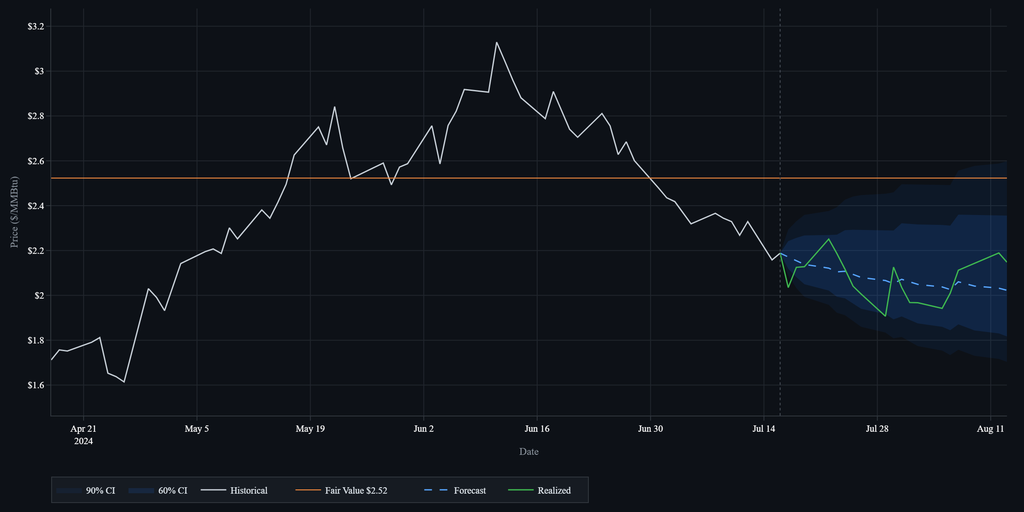

July 16, 2024 Forecast (h = 20)

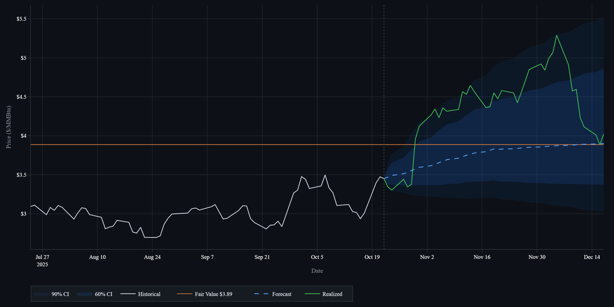

October 22, 2025 Forecast (h = 40)

## Model Architecture - Summary

The model is composed of three different sub-models. The predictions from each are weighted and combined to produce a point forecast, 60% confidence interval, and 90% confidence interval for each week in the lookahead window.

**Model A - Fair Value Regression + Mean Reversion:**

This model takes fundamental data as inputs (storage levels, rig counts, capacity utilization, and the WTI/HH ratio) and estimates a fair value price to the prompt-month contract. In other words, it predicts what the price for prompt-month gas *should be* given current supply and demand conditions, rather than what it is. When the market price does not match the fair value, the model assumes prices will revert toward it over time.

The mean reversion component is added as an AR(1) process on the gap between the log market price and log fair value:

$$\text{gap}_t = \phi \cdot \text{gap}_{t-1} + \epsilon_t$$

Where $\phi$ is the mean reversion speed estimated from the data. When $\phi$ is close to 1, this implies slow reversion, while a $\phi$ close to 0 implies rapid reversion to fair value. The estimated $\phi = 0.747$ from the data implies a half-life of approximately 2.4 weeks, meaning half of any fair value gap closes within 2.4 weeks under normal market conditions.

The final h-week ahead price forecast from Model A is:

$$\hat{P}_{t+h} = \text{exp}(\widehat{FV}_t + \phi^h \cdot\text{gap}_t) \times\frac{\text{CPI}_t}{100}$$

With

- Forecast origin $t$
- Forecast horizon in weeks $h$
- Predicted price $\hat{P}_{t+h}$
- Fair value $\widehat{FV_t}$
- Reversion speed $\phi$
- Gap size $\text{gap}_t$
- CPI (consumer price index) value $\text{CPI}_t$

**Model B - Futures Curve Interpolation:**

This model uses the NYMEX Henry Hub futures curve to generate a forward price path directly from market-implied expectations. Rather than estimating where prices should be given fundamentals, it reads where the market estimates prices will be at each future delivery month.

At each forecast origin, the four nearest contract settlements (Contract 1-Contract 4) are observed and linearly interpolated to produce a weekly price path. For instance, if Contract 1 (prompt-month) is priced at $3.00 and Contract 2 is priced at $3.40, the curve predicts prices to rise $0.40 over the next four weeks, at $0.10 per week. At h=0, the curve anchors to the current price and steps forward:

- Weeks 1-4: interpolate between Contracts 1 and 2
- Weeks 5-8: interpolate between Contracts 2 and 3
- Week 9 (up to trading day 45): interpolate between Contracts 3 and 4

A known bias in futures markets is that contango curves tend to overestimate where prices will actually settle. The spread between contracts reflects storage costs and risk premiums rather than genuine price appreciation expectations. To account for this, when the curve is in contango, a correction of 60% of the Contract 1-Contract 4 spread is applied. This correction starts at 0 for h=1 and reaches the full 60% adjustment at h=9 (where the contango bias is largest).

- At h=1: no correction, the near-term curve is reliable
- At h=9, subtract 60% of (Contract 4 - Contract 1) from the forecast

The correction was calculated empirically from the data based on the bias when no contango adjustment is included.

**Model C - Empirical Confidence Bands**

While models A and B produce point forecasts for each horizon, Model C wraps those forecasts in uncertainty bands that represent how wrong the forecast might be.

Rather than assuming returns follow a normal distribution and deriving confidence bands analytically, we use the actual historical distribution of h-day price moves directly. For each forecast horizon (h=1 to h=45), the empirical 10th, 20th, 80th, and 90th percentiles of all historical log returns over that horizon are included from the clean price history (2017-present, excluding 2022-2023 spike):

$$\text{log return} = \text{log}(\frac{P_{t+h}}{P_t})$$

$$\text{upper}_{90} = \hat{P}_{t+h} \times e^{q_{90}(h)\times\lambda}$$

$$\text{lower}_{90} = \hat{P}_{t+h} \times e^{q_{10}(h)\times\lambda}$$

Where $q_{90}(h)$ and $q_{10}(h)$ are the empirical quantiles at horizon $h$ and $\lambda = 1.15$ is a calibration multiplier chosen so that the 90% confidence band achieves approximately 90% empirical coverage at $h = 45$ from 2017-2019, which is the portion of our training data not included in our backtest.

The bands are not symmetric around the forecast. If market conditions are heavily bearish and natural gas is massively overvalued, a price decline is more likely than continued price increases. When the fair value gap is large, meaning the model has high conviction about the direction of mispricing, the band is widened on the expected side and narrowed on the other. A bullish signal widens the upper band, and a bearish signal widens the lower band. The scaling follows the equation:

$$\text{asym} = \text{tanh}(|\text{gap}| \times3) \times 0.4$$

This ensures that when the model has strong conviction, the band reflects the risk asymmetry rather than treating upside and downside as equally likely.

## Combining Forecasts

The three models serve roles and perform best at different horizons. Model A has an edge at longer horizons where fundamentals tend to dominate. Model B is more in tune with short horizons where market-implied prices closely reflect near-term physical conditions. Model C provides the uncertainty around the point forecasts.

Rather than applying fixed weights across all horizons, Model A and Model B are weighted to adjust for their importance at different horizons.

| Horizon | Model A Weight | Model B Weight |
| --- | --- | --- |
| Week 1 (h=1–5) | 0% | 100% |
| Week 2 (h=6–10) | 20% | 80% |
| Week 3 (h=11–15) | 40% | 60% |
| Week 4 (h=16–20) | 60% | 40% |
| Week 5–9 (h=21–45) | 80% | 20% |

The final combined forecast formula is:

$$\hat{P}^{combined}_{t+h} = w_A(h) \cdot \hat{P}^A_{t+h} + w_B(h) \cdot \hat{P}^B_{t+h}$$

With

- Combined price point forecast $\hat{P}^{combined}_{t+h}$
- Model A weight $w_A(h)$
- Model A point forecast $\hat{P}^A_{t+h}$
- Model B weight $w_B(h)$
- Model B point forecast $\hat{P}^B_{t+h}$

Each confidence band is wrapped around this point forecast in order to get the full predicted price outcome distributions.

## Data

There are four categories of data used in this project: fundamental data, pricing data, macro data, and structural/regime data. The list below covers both variables included in the final model and those tested and rejected during development.

**Fundamental Data:**

- EIA Weekly Natural Gas Storage
  - Source: EIA API via the `eia` package
  - Frequency: weekly
  - Coverage: 2010-present
  - Content: Working gas in storage by region and total US. Used to compute YoY storage deviation and 5-year surplus/deficit
- Baker Hughes Gas Rig Count
  - Source: EIA API via the `eia` package
  - Frequency: Weekly
  - Coverage: 2000-present
  - Content: Active natural gas drilling rigs, which is an indicator of medium/long-term supply trajectory
- EIA Natural Gas Exports
  - Source: EIA API via the `eia` package
  - Frequency: Monthly
  - Coverage: 2000-present
  - Content: Total and LNG exports in MMcf
- Daily max/min temperatures
  - Source: NOAA via the Open-Meteo Historical Weather API
  - Frequency: Daily
  - Coverage: 2010-present
  - Content: Daily max/min temperatures for Chicago, New York, and Boston, used to derive estimates for heating degree days (HDD)

**Pricing Data:**

- NYMEX Prompt-Month Continuous Futures
  - Source: Yahoo Finance via the `tidyquant` package
  - Frequency: Daily
  - Coverage: 2000-present
  - Content: Daily settlement price for the prompt-month natural gas contract
- Futures Curve (Contracts 1-4)
  - Source: EIA API via the `eia` package from 2000 to October 2022 (weekly), as well as daily settlements from November 2022 through August 2026
  - Frequency: Daily/Weekly
  - Coverage: 2000-present
  - Content: Settlement prices for the front four contract months

WTI Crude Oil Spot Price

- Source: FRED via the `fredr` package
- Frequency: Daily
- Coverage: 2000-present
- Content: WTI spot price, used to construct the WTI/HH ratio, capturing fuel switching economics

**Structural/Regime Data:**

- Season
  - Content: Categorical variable with one level for each season. Natural gas markets behave differently depending on the season, with winter being the most notable example
- Post-invasion indicator
  - Content: Natural gas prices spiked after Russia invaded Ukraine, leading to a structural shift in global LNG markets

The data was filtered to begin in 2017 to reflect the modern LNG-era market structure. Including data from further back would not be representative of the current factors that drive market conditions.

## Feature Building

After compiling and cleaning the data, the next step was to build features. The response variable in this case is `log_real_price`, which is the prompt-month price adjusted for inflation using the monthly CPI figure. Gas prices drift with general inflation. Deflating removes this trend so that we can capture supply/demand-driven price variation rather than inflation-driven variation. Natural gas prices are also right-skewed and multiplicatively-scaled, meaning a move from $2.00 to $3.00 is equivalent to a move from $4.00 to $6.00 (50% increase). A log transformation stabilizes variance and ensures that the data are approximately normally distributed for linear regression.

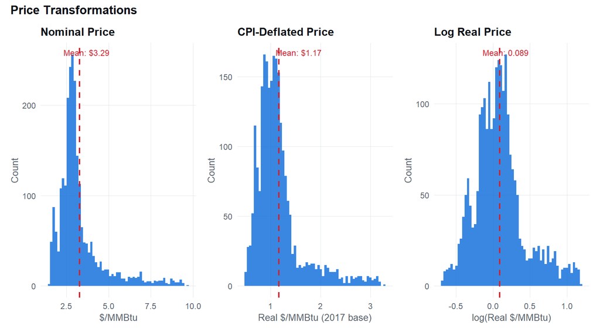

A log transformation of the data produces the cleanest distribution for linear regression. There remains a heavy right tail, due to the 2022-2023 price spike, which is worth noting.

After creating new features and merging data sets, the master panel included the following variables for correlation/significance testing:

| Feature | Description | Category |
| --- | --- | --- |
| `total` | Total US working gas in storage (Bcf) | Fundamental |
| `storage_yoy` | Year-over-year change in storage level (Bcf) | Fundamental |
| `storage_5yr_surplus` | Deviation from 5-year average storage level (Bcf) | Fundamental |
| `hdd_pop` | City-weighted heating degree days | Fundamental |
| `hdd_pop_dev` | City-weighted HDD deviation from seasonal normal | Fundamental |
| `hdd_gas_dev` | Gas-consumption-weighted HDD deviation from seasonal normal | Fundamental |
| `cdd_pop_dev` | City-weighted cooling degree day deviation from seasonal normal | Fundamental |
| `dry_production` | Weekly dry gas production estimate (Bcf/d) | Fundamental |
| `log_gas_rigs` | Log of active gas drilling rigs | Fundamental |
| `rig_count_13wk_ma` | 13-week moving average of active gas rigs | Fundamental |
| `lng_exports` | Monthly LNG export volumes (MMcf) | Fundamental |
| `log_lng_exports` | Log of monthly LNG export volumes | Fundamental |
| `total_exports` | Total natural gas exports including pipeline (MMcf) | Fundamental |
| `c1_price` | Nominal front-month NYMEX futures settlement price ($/MMBtu) | Pricing |
| `log_real_price` | Log of CPI-deflated C1 futures price | Pricing |
| `log_price_lag1` | Log real price lagged 1 week | Pricing |
| `log_price_lag4` | Log real price lagged 4 weeks | Pricing |
| `rolling_20d_vol` | 20-day realized volatility of daily log returns | Pricing |
| `c1_c4_spread` | C4 minus C1 settlement price ($/MMBtu) | Pricing |
| `spot_c1_basis` | Spot price minus C1 settlement price ($/MMBtu) | Pricing |
| `log_wti_hh` | Log of WTI crude oil price divided by Henry Hub × 6 | Pricing/Macroeconomic |
| `tcu` | Total industrial capacity utilization (%) | Macroeconomic |
| `season_winter` | Binary indicator — December, January, February | Structural/Regime |
| `season_summer` | Binary indicator — June, July, August | Structural/Regime |
| `season_fall` | Binary indicator — September, October, November | Structural/Regime |
| `post_invasion` | Binary indicator — February 28 2022 onward | Structural/Regime |

## Feature Selection - Model A

In order to evaluate which fundamental features were worth including in Model A, each was evaluated for statistical significance, high correlation, correct sign, and economic plausibility. The goal was a parsimonious model, one that explained as much variation in price as possible with as few variables as needed.

**1. Screening**

Before finalizing any variables for Model A, the set of candidate variables was selected based on established market fundamentals. Each variable has a clear directional hypothesis:

- Storage deviation - more gas = lower prices
- Weather demand - more CDD/HDD = higher prices
- Rig count - more drilling = more long-term gas supply = lower prices
- Capacity utilization
- Stronger economy = more demand = higher prices
- Seasonal indicators - heating/cooling season premiums
- LNG exports - export demand pulls away domestic gas = higher prices
- Production - more supply = lower prices

**2. Baseline Model:**

The starting point was the above set of theoretically motivated variables drawn from natural gas forecasting literature.

Baseline Model | R² = 0.634 | Adj R² = 0.625

| Variable | p-value |
| --- | --- |
| storage_yoy | 0.0000 |
| hdd_pop_dev | 0.0518 |
| cdd_pop_dev | 0.5905 |
| log_gas_rigs | 0.0354 |
| tcu | 0.4908 |
| seasonsummer | 0.0151 |
| seasonfall | 0.0000 |
| seasonwinter | 0.0000 |
| log_lng_exports | 0.9863 |
| log_dry_production | 0.1601 |

Candidates from the master data set were added to the baseline one at a time and evaluated for its marginal $R^2$ contribution. The goal was to determine whether or not adding the variable meaningfully improved the model’s ability to explain real gas prices.

**The WTI/HH ratio**

Natural gas and crude oil are partial substitutes in industrial and power generation applications. When oil becomes expensive relative to gas, large energy consumers switch from oil to gas, increasing gas demand and pushing prices higher. The opposite effect occurs when gas is expensive relative to oil. The ratio of WTI oil prices to Henry Hub prices seemed like it might hold explanatory power not captured by existing variables in the base model. The ratio is:

$$\text{log\_wti\_hh} = \text{log}(\frac{WTI}{\text{HH} \times 6})$$

The denominator is multiplied by 6 to convert from $/MMBtu to barrel-equivalent energy terms. A high ratio means oil is expensive relative to gas, while a low ratio means gas is expensive relative to oil. We expect the fuel switching demand to pull prices back together.

Adding WTI/HH to the model results in several variables that were insignificant before (such as `log_lng_exports`) becoming significant, as well as the adjusted $R^2$ increasing from 0.624 to 0.798.

Baseline + WTI/HH | R² = 0.804 | Adj R² = 0.799

| Variable | Coefficient | p-value |
| --- | --- | --- |
| storage_yoy | -0.00032 | 0.0000 |
| hdd_pop_dev | -0.00011 | 0.7111 |
| cdd_pop_dev | 0.00044 | 0.5963 |
| log_gas_rigs | -0.02020 | 0.5684 |
| tcu | 0.02003 | 0.0000 |
| seasonsummer | 0.05910 | 0.0003 |
| seasonfall | 0.15445 | 0.0000 |
| seasonwinter | 0.09703 | 0.0000 |
| log_lng_exports | 0.07441 | 0.0076 |
| log_dry_production | -0.39202 | 0.0117 |
| log_wti_hh | -0.39504 | 0.0000 |

From the table above, we can see that `hdd_pop_dev`, `cdd_pop_dev`, and `log_gas_rigs` are not significant at $\alpha=0.05$. Next, we perform a VIF test to see which variables show signs of multicollinearity. A VIF value greater than 10 is a very strong indicator of multicollinearity.

| Variable | VIF |
| --- | --- |
| log_lng_exports | 14.48 |
| log_dry_production | 12.66 |
| log_gas_rigs | 3.50 |
| tcu | 2.53 |
| storage_yoy | 2.01 |
| log_wti_hh | 1.46 |
| season | 1.43 |
| hdd_pop_dev | 1.09 |
| cdd_pop_dev | 1.06 |

Final Model | R² = 0.8 | Adj R² = 0.797

| Variable | Coefficient | p-value |
| --- | --- | --- |
| storage_yoy | -0.00033 | 0.0000 |
| tcu | 0.02080 | 0.0000 |
| log_gas_rigs | -0.06548 | 0.0129 |
| seasonsummer | 0.05166 | 0.0012 |
| seasonfall | 0.13469 | 0.0000 |
| seasonwinter | 0.08687 | 0.0000 |
| log_wti_hh | -0.38685 | 0.0000 |

This reduced model has essentially the same $R^2$ (0.800) and adjusted $R^2$ (0.797) values as the previous full model, while being more parsimonious. This is the final framework used in Model A to make point forecasts.

## Model Performance

**Backtest methodology**

Model performance was evaluated using a rolling in-sample backtest covering daily forecast origins in a 2020-2026 training window. At each origin date, the full pipeline was run using only data available on that date (fundamentals, futures curve, and confidence bands) and the resulting forecast was compared against actual settlement prices at each horizon.

It is important to note that this is technically an in-sample backtest since the fair value regression in Model A was estimated on the same data. This was done for the purposes of limited time and training data, although refitting the model at each origin would provide a more conservative and rigorous estimate of predictive ability.

The fair value model was estimated on data from January 2017 onward to maximize training sample size, especially since many fundamental variables are only updated weekly/monthly. However, performance evaluation focuses on the 2020-present period, which reflects the modern LNG-era structure the model is designed to predict.

The 2022-2023 price spike, which spanned roughly February 2022 through June 2023, was excluded from the backtest since it was an anomalous period of high prices and volatility.

Performance was evaluated across forecast horizons h = 5, 10, 20, and 45 trading days using three metrics:

- Directional accuracy - Percentage of the point forecasts where the predicted direction of price movement matched the actual direction at the target horizon
- Median RMSPE - The median ratio of the model’s absolute forecast error to the random walk’s absolute forecast error. A value below 1.0 means the model’s errors are smaller than the random walk on average. The random walk predicts that tomorrow’s price equals today’s price
- 90% CI coverage - The percentage of actual settlement prices that fell within the stated 90% confidence band. A well-calibrated model should achieve approximately 90% coverage.

**Results/Analysis**

Overall Model Performance by Horizon Window — 2020 to Present

| Horizon Window | N | Direction % | Mean Error | Median RMSPE | Beats RW | 90% Coverage | 60% Coverage |
| --- | --- | --- | --- | --- | --- | --- | --- |
| Short (h=5–10) | 2504 | 54.5% | $-0.014 | 1.021 | 48% | 82.7% | 60.9% |
| Medium (h=15–20) | 2504 | 57.9% | $0.004 | 0.976 | 52% | 85.4% | 66% |
| Medium-Long (h=25–35) | 3756 | 62.6% | $0.04 | 0.953 | 53.6% | 86.3% | 65.1% |
| Long (h=40–45) | 2503 | 63.7% | $0.031 | 0.936 | 54.9% | 89.9% | 65% |

Overall, the model achieves 54.5-63.7% directional accuracy and edges out the random walk by 2.0-4.9% across all horizons except short (h=5-10). The confidence intervals appear slightly miscalibrated, but are roughly near their 60% and 90% targets.

Performance by Season and Horizon Window — 2020 to Present

| Season | Group | N | Direction % | Mean Error | Median RMSPE | Beats RW | 90% Coverage |
| --- | --- | --- | --- | --- | --- | --- | --- |
| Spring | ALL HORIZONS | 2844 | 63.9% | $0.034 | 0.960 | 53.7% | 88.2% |
| Spring | Short (h=5–10) | 632 | 60.9% | $0.006 | 0.966 | 54.3% | 88.3% |
| Spring | Medium (h=15–20) | 632 | 63.9% | $0.037 | 0.923 | 57% | 88.4% |
| Spring | Medium-Long (h=25–35) | 948 | 63.8% | $0.054 | 0.979 | 51.4% | 86.7% |
| Spring | Long (h=40–45) | 632 | 66.8% | $0.027 | 0.971 | 53.2% | 89.9% |
| Summer | ALL HORIZONS | 2834 | 61.7% | $-0.073 | 0.951 | 56.1% | 93.9% |
| Summer | Short (h=5–10) | 630 | 49.8% | $-0.061 | 1.091 | 44.1% | 89.7% |
| Summer | Medium (h=15–20) | 630 | 55.9% | $-0.067 | 0.995 | 50.6% | 93.2% |
| Summer | Medium-Long (h=25–35) | 945 | 67.8% | $-0.056 | 0.929 | 61.9% | 95.2% |
| Summer | Long (h=40–45) | 629 | 70.1% | $-0.118 | 0.902 | 64.9% | 96.8% |
| Fall | ALL HORIZONS | 2844 | 60.3% | $0.087 | 0.956 | 53.1% | 84.1% |
| Fall | Short (h=5–10) | 632 | 53.3% | $0.016 | 1.059 | 44.5% | 78.6% |
| Fall | Medium (h=15–20) | 632 | 58.9% | $0.074 | 0.946 | 53% | 81.2% |
| Fall | Medium-Long (h=25–35) | 948 | 62.1% | $0.112 | 0.922 | 55% | 84.9% |
| Fall | Long (h=40–45) | 632 | 65.8% | $0.134 | 0.850 | 58.9% | 91.3% |
| Winter | ALL HORIZONS | 2745 | 54.1% | $0.025 | 1.054 | 46.2% | 78% |
| Winter | Short (h=5–10) | 610 | 53.9% | $-0.017 | 1.010 | 49.2% | 74.1% |
| Winter | Medium (h=15–20) | 610 | 53% | $-0.028 | 1.032 | 47.2% | 78.5% |
| Winter | Medium-Long (h=25–35) | 915 | 56.5% | $0.05 | 1.129 | 46% | 78.3% |
| Winter | Long (h=40–45) | 610 | 51.6% | $0.083 | 1.162 | 42.5% | 81.1% |

Looking at the table above, all seasons except winter show above 60% directional accuracy and beat the random walk over 50% of the time. Winter has a directional accuracy of only 54% and median RMSPE of 1.054, meaning the model shows a noticeable dip in performance during winter months.

Performance by Month — All Horizons Combined — 2020 to Present

| Month | N | Direction % | Mean Error | Median RMSPE | Beats RW | 90% Coverage |
| --- | --- | --- | --- | --- | --- | --- |
| Jan | 918 | 59.6% | $0.087 | 0.915 | 52.4% | 67.3% |
| Feb | 864 | 43.5% | $0.123 | 1.155 | 37.3% | 79.2% |
| Mar | 972 | 60.4% | $0.2 | 1.010 | 48.5% | 87.2% |
| Apr | 945 | 64.9% | $-0.064 | 0.934 | 56% | 85.1% |
| May | 927 | 66.5% | $-0.042 | 0.911 | 56.7% | 92.2% |
| Jun | 881 | 59.6% | $0.094 | 0.977 | 53.8% | 93.5% |
| Jul | 972 | 66.7% | $-0.06 | 0.933 | 60.2% | 95.4% |
| Aug | 981 | 58.6% | $-0.237 | 0.937 | 54.1% | 92.8% |
| Sep | 927 | 71.8% | $-0.171 | 0.831 | 63.2% | 90.7% |
| Oct | 999 | 62.3% | $0.069 | 0.862 | 54.6% | 87.5% |
| Nov | 918 | 46.4% | $0.368 | 1.123 | 41.2% | 73.7% |
| Dec | 963 | 58.3% | $-0.122 | 1.031 | 48.3% | 87.2% |

Breaking down the results further, we can see that February and November stand out as particularly weak prediction months. This is worth noting when forecasting prices, since the model may not be more reliable than a random walk or directional guess.

Finally, we will look at a scatterplot of the actual settlement prices versus the model’s predicted values.

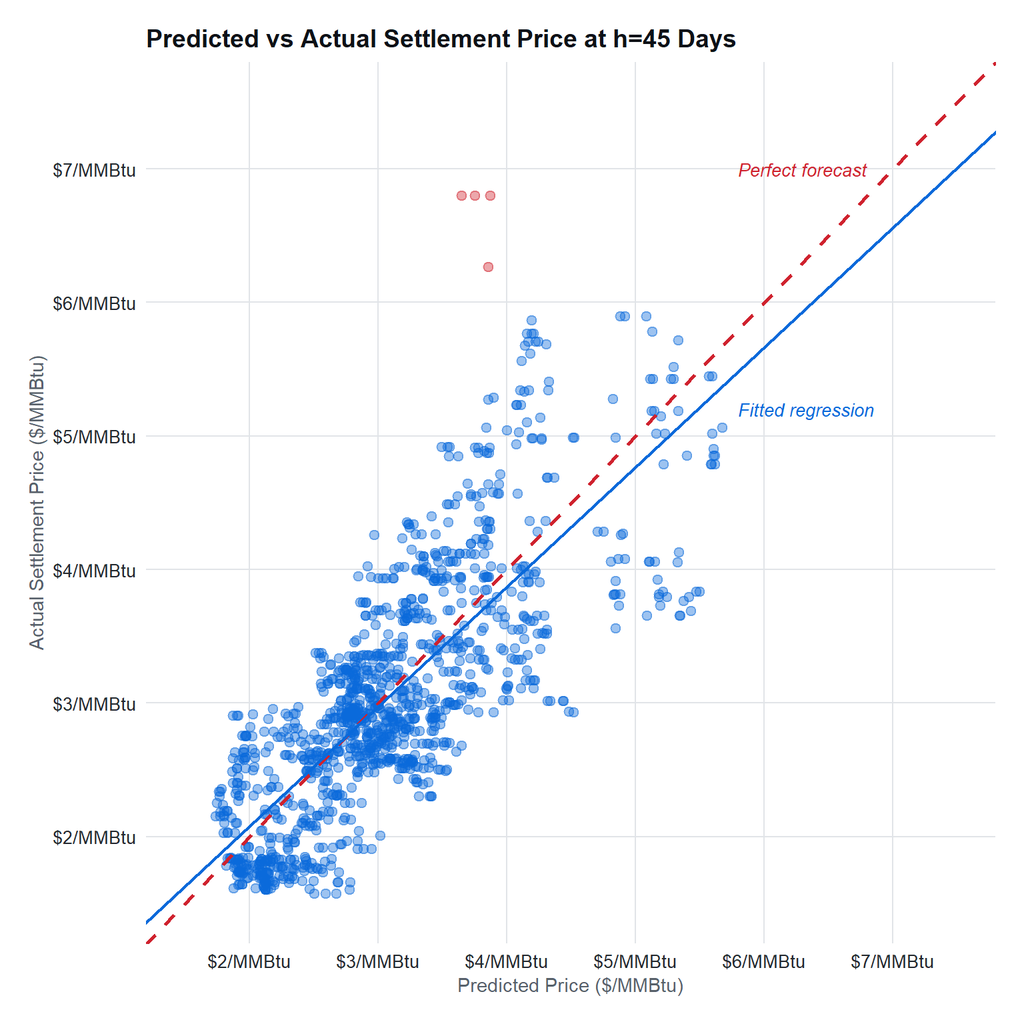

**Conclusion**

Overall, the model shows strong results in several settings, consistently predicting the correct direction and beating the random walk. Winter is the weakest prediction season by a large margin, while February and November stand out as the weakest individual prediction months. The model shows much better performance at long horizons than short horizons. There is a slight upward bias in model predictions, but the relationship between actual and predicted values at h=45 is linear, positive, and fairly strong. This model should be mostly relied upon for medium/long-term predictions in summer and shoulder months, although it is important to reference its specific monthly metrics to get a sense of how it performs in that particular time frame.

## Assumptions, Limitations, and Future Work

**Assumptions**

**Limitations**

- Winter forecasting - The model’s most significant limitation is its performance in winter (especially February) relative to other seasons. Winter natural gas prices are largely driven by realized weather outcomes, and this information is not available 45 days in advance from any free data source.
- In-sample evaluation - The backtest is in-sample, meaning its results are skewed favorably towards the model and may not reflect true out-of-sample performance.
- Weak short-term signal - Model performance is strongest at longer horizons, when fundamental conditions have had time to assert themselves. At h=5, the model only has a very slight edge in directional accuracy.
- Free data constraint - The project was deliberately constrained to free data sources. Full historical futures curve data, weather forecasts, real-time pipeline flows, and LNG cargo tracking would be possible with paid data.

**Future work**

- Rolling re-estimation - This includes an out-of-sample backtest that refits the model at each origin date.
- Winter forecasting improvement - Incorporating more detailed weather data and perhaps introducing a separate winter model may improve performance in these months.
- Confidence band refinement - The current empirical confidence bands use unconditional historical return quantiles, which assume the same distribution across all seasons/months. A larger sample size could make an alternative approach feasible.